# Mitochondrial deletions in human tissues

Gonzalo S. Nido

2025-02-19

## Upstream methods

### Long-reads sequencing (ONT)

For the ONT samples, (unmodified) raw sequences were extracted from fast5 files, trimmed using **chopper** to remove low quality bases from the reads. Alignments were carried out using **minimap2** against the mitochondrial chromosome (rCRS) and the chr22 autosome. Due to the circular nature of the mitochondrial chromosome, reads were aligned in parallel to an alternative version of the rCRS whose start-end positions were shifted by 8,000 bp. This allowed long reads spanning over the arbitrary start-end regions in the rCRS to be properly aligned. Only primary alignments were considered (SAM flags 0 and 16).

SNV calling was carried out using GATK **Mutect2** in mitochondria mode for each of the three alignments (rCRS, shifted rCRS and chr22). The variants in the VCF resulting from the alignments of long reads against the 8,000 bp-shifted rCRS were lifted over to the original rCRS coordinates. A final set of mtDNA variants was obtained by combining variants within positions 4,000-11,999 from the standard rCRS reference, and within 1-3,999 and 12,000-16,569 from the alignment against the 8,000 bp-shifted reference. **Haplocheck** was used to test for haplotype contamination in the resulting filtered mtDNA variants.

To use as a nuclear control, we used the same methodology to call SNVs in a short region from the chr22 (chr22:20,000,000-20,100,000).

To obtain deletions at the single-read level from the ONT data, we parsed the sam CIGAR strings in the mitomap2 alignments using a custom script. Similarly, we parsed CIGAR strings to obtain the number of matching (=) and mismatching (X) positions in each single-read alignment.

See **PIPELINE_short.sh** for the commands used. Scripts and executables are located in the bin/ folder.

### Illumina samples

The two EDTA blood samples sequenced using Illumina NGS technology were aligned against the whole genome using the GATK recommended guidelines, following the mitochondrial-specific pipeline for variant calling.

## Sample information

Metadata with sample information:

```r
Metadata <- read_csv("./Tables/Metadata.txt", col_types = "cccc") %>%
    mutate(tissue = ifelse(str_starts(tissue, "edta_blood"), "edta_blood", tissue)) %>%
    mutate(platform = seq) %>%
    select(-seq)
Metadata %>%
    arrange(platform, tissue) %>%
    kable(caption = "Sample overview") %>%
    kable_styling(bootstrap_options = "striped", full_width = FALSE)
```

Sample overview

| sample_id | tissue | individual_id | platform |
| --- | --- | --- | --- |
| SL443862 | edta_blood | c | illumina |
| SL443863 | edta_blood | d | illumina |
| 6226-CT-0010 | PFC | a | ont |
| 6226-CT-0018 | cerebellum | b | ont |
| 6226-CT-0015 | colon | b | ont |
| 6226-CT-0016 | edta_blood | c | ont |
| 6226-CT-0017 | edta_blood | d | ont |
| 6226-CT-0011 | heart | b | ont |
| 6226-CT-0014 | kidney | b | ont |
| 6226-CT-0013 | liver | b | ont |
| 6226-CT-0012 | muscle | b | ont |

NOTE: sample from PFC is from a different individual (**a**), and EDTA blood samples (both Illumina and ONT sequencing samples) are yet from different individuals (**c** and **d**).

## DNA Coverage

The following plot shows the rCRS coverage for all ONT samples (including those belonging to different individuals and tissues). Different colours correspond to different individuals.

Depth of coverage is calculated using *samtools depth* on both mtDNA alignments (rCRS and shifted rCRS), but positions are subsetted to 4,000-12,000 for the rCRS and 4,000-12,569 for the shifted rCRS, which correspond to chrM:1-4000 and chrM:12,000-16,569 when shifted back).

Depth of coverage for chr22 is restricted to chr22:20,000,000-20,100,000 for simplicity.

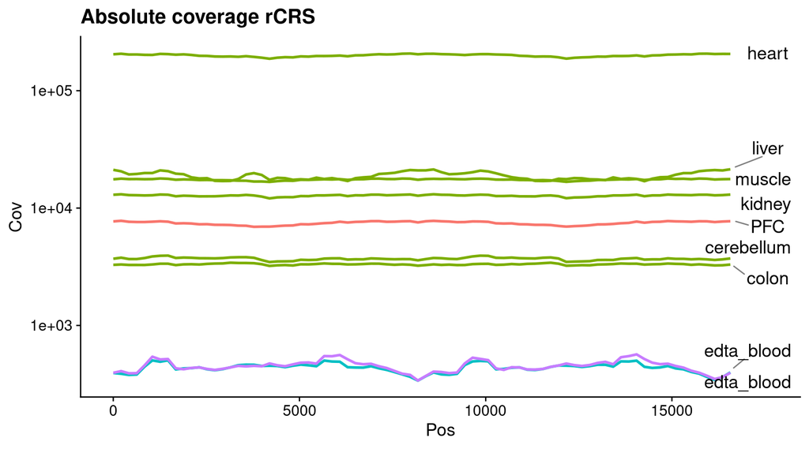

```r
depthFiles1 <- paste0("../results/depth/",
                      filter(Metadata, platform == "ont")$sample_id,
                      "_chrM.txt")
names(depthFiles1) <- filter(Metadata, platform == "ont")$sample_id
#all(file.exists(depthFiles1))

depthFiles2 <- paste0("../results/depth/",
                      filter(Metadata, platform == "ont")$sample_id,
                      "_chrM_shifted.txt")
names(depthFiles2) <- filter(Metadata, platform == "ont")$sample_id
#all(file.exists(depthFiles2))

depthFiles22 <- paste0("../results/depth/",
                       filter(Metadata, platform == "ont")$sample_id,
                       "_chr22.txt")
names(depthFiles22) <- filter(Metadata, platform == "ont")$sample_id
#all(file.exists(depthFiles22))

Cov <- bind_rows(
    lapply(names(depthFiles1), function(sid) {
        read_tsv(depthFiles1[sid], col_names = FALSE, col_types = "cii") %>%
            mutate(sample_id = sid) %>%
            select(Pos = X2, Cov = X3, sample_id) %>%
            filter(Pos >= 4000, Pos < 12000)
    }) %>% Reduce("bind_rows", .),
    lapply(names(depthFiles2), function(sid) {
        read_tsv(depthFiles1[sid], col_names = FALSE, col_types = "cii") %>%
            mutate(sample_id = sid) %>%
            select(Pos = X2, Cov = X3, sample_id) %>%
            filter(Pos >= 4000, Pos < 12569) %>%
            mutate(Pos = sapply(Pos, us8k))
    }) %>% Reduce("bind_rows", .)
) %>% filter(Pos != 3107) %>%
    arrange(sample_id, Pos)

plotLabels <- left_join(Cov, select(Metadata, sample_id, tissue, individual_id), by = join_by(sample_id)) %>%
    group_by(tissue) %>%
    filter(Pos == 16569) %>%
    ungroup()

Plot1 <- left_join(Cov, Metadata, by = join_by(sample_id)) %>%
    ggplot() +
    geom_smooth(aes(x = Pos, y = Cov, group = sample_id, colour = individual_id),
        method = "gam", formula = y ~ s(x, bs = "cs", fx = TRUE, k = 100), se = FALSE) +
    geom_text_repel(data = plotLabels, aes(x = Pos, y = Cov, label = tissue),
        nudge_x = 1000, direction = "y",
        box.padding = 0.5, point.padding = 0.5,
        segment.color = "grey50", size = 5) +
    scale_y_log10() +
    theme_cowplot() +
    theme(legend.position = "none") +
    ggtitle("Absolute coverage rCRS")
Plot1
```

```r
# invisible(svg("./Figs/coverage_ONT_all.svg", height = 6, width = 12))
# Plot1
# invisible(dev.off())
invisible(png("./Figs/coverage_ONT_all.png", height = 1000, width = 2000, res = 150))
Plot1
invisible(dev.off())
```

The high levels of coverage seen in the the mitochondrial chromosome contrast with the more sparse nuclear coverage. Based on the 100,000bp region from chr22, the nuclear genome has a coverage of 1-3 orders of magnitude lower.

In addition, the nuclear coverage is much more similar across different tissues than the mitochondrial, which exhibits very large differences (e.g., ~400X in EDTA blood vs ~200,000X in heart tissue).

The following table displays summary statistics for both the rCRS coverage (top) and the 100,000bp region in chr22 (bottom).

```r
Cov22 <- lapply(names(depthFiles22), function(sid) {
    read_tsv(depthFiles22[sid], col_names = FALSE, col_types = "cii") %>%
        mutate(sample_id = sid) %>%
        select(Pos = X2, Cov = X3, sample_id)
}) %>% Reduce("bind_rows", .)

summTable <- left_join(Cov, Metadata, by = join_by(sample_id)) %>%
    group_by(sample_id) %>%
    summarise(mean_cov = round(mean(Cov)),
              stdev_cov = round(sd(Cov))) %>%
    ungroup() %>%
    left_join(Metadata, by = join_by(sample_id)) %>%
    select(tissue, individual_id, sample_id, mean_cov, stdev_cov)

summTable22 <- left_join(Cov22, Metadata, by = join_by(sample_id)) %>%
    group_by(sample_id) %>%
    summarise(mean_cov = round(mean(Cov)),
              stdev_cov = round(sd(Cov))) %>%
    ungroup() %>%
    left_join(Metadata, by = join_by(sample_id)) %>%
    select(tissue, individual_id, sample_id, mean_cov, stdev_cov)

summTable %>%
    kable(caption = "Summary statistics rCRS coverage per sample") %>%
    kable_styling(bootstrap_options = "striped", full_width = FALSE)
```

Summary statistics rCRS coverage per sample

| tissue | individual_id | sample_id | mean_cov | stdev_cov |
| --- | --- | --- | --- | --- |
| PFC | a | 6226-CT-0010 | 7456 | 407 |
| heart | b | 6226-CT-0011 | 199966 | 9417 |
| muscle | b | 6226-CT-0012 | 17489 | 723 |
| liver | b | 6226-CT-0013 | 18876 | 1559 |
| kidney | b | 6226-CT-0014 | 12790 | 574 |
| colon | b | 6226-CT-0015 | 3321 | 135 |
| edta_blood | c | 6226-CT-0016 | 436 | 44 |
| edta_blood | d | 6226-CT-0017 | 452 | 55 |
| cerebellum | b | 6226-CT-0018 | 3705 | 178 |

```r
summTable22 %>%
    kable(caption = "Summary statistics chr22:20,000,000-20,100,000 coverage per sample") %>%
    kable_styling(bootstrap_options = "striped", full_width = FALSE)
```

Summary statistics chr22:20,000,000-20,100,000 coverage per sample

| tissue | individual_id | sample_id | mean_cov | stdev_cov |
| --- | --- | --- | --- | --- |
| PFC | a | 6226-CT-0010 | 63 | 105 |
| heart | b | 6226-CT-0011 | 111 | 201 |
| muscle | b | 6226-CT-0012 | 81 | 155 |
| liver | b | 6226-CT-0013 | 60 | 105 |
| kidney | b | 6226-CT-0014 | 114 | 208 |
| colon | b | 6226-CT-0015 | 42 | 76 |
| edta_blood | c | 6226-CT-0016 | 39 | 70 |
| edta_blood | d | 6226-CT-0017 | 40 | 72 |
| cerebellum | b | 6226-CT-0018 | 87 | 163 |

## Mitochondrial copy number estimation

The coverage data can be used to estimate the a relative copy number across tissues by normalising mtDNA:nuclear coverage. This represents only a relative copy number estimate of the **average in the tissue** (i.e., different cell types within a tissue have different mtDNA copy numbers).

```r
summTable_ont <- summTable %>% select(tissue, individual_id, sample_id, mean_cov_MT = mean_cov) %>%
    full_join(summTable22 %>% select(tissue, individual_id, sample_id, mean_cov_chr22 = mean_cov),
              by = join_by(tissue, individual_id, sample_id)) %>%
    mutate(relative_copynumber = round(mean_cov_MT/mean_cov_chr22))
summTable_ont %>%
    kable(caption = "Relative mtDNA copy number based on avg. depth of coverage") %>%
    kable_styling(bootstrap_options = "striped", full_width = FALSE)
```

Relative mtDNA copy number based on avg. depth of coverage

| tissue | individual_id | sample_id | mean_cov_MT | mean_cov_chr22 | relative_copynumber |
| --- | --- | --- | --- | --- | --- |
| PFC | a | 6226-CT-0010 | 7456 | 63 | 118 |
| heart | b | 6226-CT-0011 | 199966 | 111 | 1801 |
| muscle | b | 6226-CT-0012 | 17489 | 81 | 216 |
| liver | b | 6226-CT-0013 | 18876 | 60 | 315 |
| kidney | b | 6226-CT-0014 | 12790 | 114 | 112 |
| colon | b | 6226-CT-0015 | 3321 | 42 | 79 |
| edta_blood | c | 6226-CT-0016 | 436 | 39 | 11 |
| edta_blood | d | 6226-CT-0017 | 452 | 40 | 11 |
| cerebellum | b | 6226-CT-0018 | 3705 | 87 | 43 |

Is the mtDNA copy number estimation similar in Illumina-based sequencing? We can use the samples for which we have both ONT and Illumina to investigate this.

```r
depthFiles_wgs_1 <- paste0("../results/depth/",
                           filter(Metadata, platform == "illumina")$sample_id,
                           "_chrM.txt")
names(depthFiles_wgs_1) <- filter(Metadata, platform == "illumina")$sample_id
#all(file.exists(depthFiles_wgs_1))

depthFiles_wgs_2 <- paste0("../results/depth/",
                           filter(Metadata, platform == "illumina")$sample_id,
                           "_chrM_shifted.txt")
names(depthFiles_wgs_2) <- filter(Metadata, platform == "illumina")$sample_id
#all(file.exists(depthFiles_wgs_2))

depthFiles_wgs_22 <- paste0("../results/depth/",
                            filter(Metadata, platform == "illumina")$sample_id,
                            "_chr22.txt")
names(depthFiles_wgs_22) <- filter(Metadata, platform == "illumina")$sample_id
#all(file.exists(depthFiles_wgs_22))


## COVERAGE / SUMMARY STATS
Cov_wgs <- bind_rows(
    Cov_wgs_1 <- lapply(names(depthFiles_wgs_1), function(sid) {
        read_tsv(depthFiles_wgs_1[sid], col_names = FALSE, col_types = "cii") %>%
            mutate(sample_id = sid) %>%
            select(Pos = X2, Cov = X3, sample_id) %>%
            filter(Pos >= 4000, Pos < 12000)
    }) %>% Reduce("bind_rows", .),
    Cov_wgs_2 <- lapply(names(depthFiles_wgs_2), function(sid) {
        read_tsv(depthFiles_wgs_2[sid], col_names = FALSE, col_types = "cii") %>%
            mutate(sample_id = sid) %>%
            select(Pos = X2, Cov = X3, sample_id) %>%
            filter(Pos >= 4000, Pos < 12569) %>%
            mutate(Pos = sapply(Pos, us8k))
    })
) %>% filter(Pos != 3107) %>%
    arrange(sample_id, Pos)

Cov_wgs_22 <- lapply(names(depthFiles_wgs_22), function(sid) {
    read_tsv(depthFiles_wgs_22[sid], col_names = FALSE, col_types = "cii") %>%
        mutate(sample_id = sid) %>%
        select(Pos = X2, Cov = X3, sample_id)
}) %>% Reduce("bind_rows", .)

summTable_wgs <- left_join(Cov_wgs, Metadata, by = join_by(sample_id)) %>%
    group_by(sample_id) %>%
    summarise(mean_cov = round(mean(Cov)),
              stdev_cov = round(sd(Cov))) %>%
    ungroup() %>%
    left_join(Metadata, by = join_by(sample_id)) %>%
    select(tissue, individual_id, sample_id, mean_cov, stdev_cov)

summTable_wgs_22 <- left_join(Cov_wgs_22, Metadata, by = join_by(sample_id)) %>%
    group_by(sample_id) %>%
    summarise(mean_cov = round(mean(Cov)),
              stdev_cov = round(sd(Cov))) %>%
    ungroup() %>%
    left_join(Metadata, by = join_by(sample_id)) %>%
    select(tissue, individual_id, sample_id, mean_cov, stdev_cov)

summTable_illumina <- summTable_wgs %>% select(tissue, individual_id, sample_id, mean_cov_MT = mean_cov) %>%
    full_join(summTable_wgs_22 %>% select(tissue, individual_id, sample_id, mean_cov_chr22 = mean_cov),
              by = join_by(tissue, individual_id, sample_id)) %>%
    mutate(relative_copynumber = round(mean_cov_MT/mean_cov_chr22))

bind_rows(summTable_illumina, summTable_ont) %>% filter(tissue == "edta_blood") %>%
    left_join(Metadata %>% select(sample_id, platform), by = join_by(sample_id)) %>%
    select(individual_id, platform, cov_MT = mean_cov_MT,
           cov_chr22 = mean_cov_chr22, copy_nr = relative_copynumber) %>%
    pivot_wider(names_from = platform, values_from = c(cov_MT, cov_chr22, copy_nr)) %>%
    kable(caption = "Relative mtDNA copy number in EDTA blood samples (ONT and Illumina)") %>%
    kable_styling(bootstrap_options = "striped", full_width = FALSE)
```

Relative mtDNA copy number in EDTA blood samples (ONT and Illumina)

| individual_id | cov_MT_illumina | cov_MT_ont | cov_chr22_illumina | cov_chr22_ont | copy_nr_illumina | copy_nr_ont |
| --- | --- | --- | --- | --- | --- | --- |
| c | 6325 | 436 | 46 | 39 | 138 | 11 |
| d | 6433 | 452 | 45 | 40 | 143 | 11 |

These results indicate a stark contrast between the two sequencing technologies in their relative coverages of the nuclear and mitochondrial genomes. According to the typically observed values (around 100, [source](https://pubmed.ncbi.nlm.nih.gov/27736919/)), it seems that Illumina is more accurate and ONT is biased towards nuclear DNA.

## Mutational load and error

Due to a higher error rate in long-read technology (at least compared to Illumina NGS sequencing technology), it is not possible to confidently estimate mutational loads. However, it is still possible to study relative mutational loads across tissues.

### Sequencing error

First, we can compare the error rate of ONT and Illumina sequencing platfoms by leveraging on the EDTA blood samples from the same 2 individuals. The sequencing error rate is here estimated using the chr22:20,000,000-20,100,000 region, which should only exhibit diploid genotypes. Only positions with a coverage within two standard deviations of the mean coverage are considered. We then calculate the number of erroneous calls as the bases that are different from the genotype.

The following table shows the error rate calculated based on this region.

```r
perNucFiles <- paste0("../results/depth/",
                      filter(Metadata, tissue == "edta_blood")$sample_id,
                      "_per_nuc_depth_chr22.txt")
names(perNucFiles) <- filter(Metadata, tissue == "edta_blood")$sample_id
#all(file.exists(perNucFiles))


perNucCov <- lapply(names(perNucFiles), function(sid) {
    read_tsv(perNucFiles[sid], col_select = c(1,2,4,6,8,10),
             c("seq", "pos", "a", "A", "c", "C", "g", "G", "t", "T")) %>%
        mutate(sample_id = sid)
}) %>% Reduce("bind_rows", .)
perNucCov_filt <- perNucCov %>% mutate(Cov = A + C + G + T) %>%
    group_by(sample_id) %>%
    mutate(mean_cov = mean(Cov), std_cov_2 = 2*sd(Cov)) %>%
    mutate(keep = ifelse(Cov > (mean_cov - std_cov_2) & Cov < (mean_cov + std_cov_2), TRUE, FALSE)) %>%
    filter(keep, Cov > 0) %>%
    select(-mean_cov, -std_cov_2, -keep) %>%
    ungroup()

errors_per_base <- perNucCov_filt %>%
    pivot_longer(A:T, names_to = "base", values_to = "count") %>%
    arrange(sample_id, pos, desc(count)) %>%
    group_by(sample_id, pos) %>%
    mutate(hom_GT = base[1], het_GT = ifelse(count[2] > 0, base[2], NA)) %>%
    mutate(hom_right = count[1]) %>%
    mutate(het_right = ifelse(!is.na(het_GT), min(Cov[1]/2,count[1])+min(Cov[1]/2,count[2]), NA)) %>%
    select(sample_id, pos, Cov, hom_right, het_right) %>%
    distinct() %>%
    mutate(right = pmax(hom_right, het_right, na.rm = TRUE)) %>%
    mutate(wrong = Cov - right) %>%
    select(-hom_right, -het_right)

errors_per_base %>% group_by(sample_id) %>%
    summarise(error_rate = formatC(sum(wrong)/sum(Cov), digits = 2)) %>%
    left_join(Metadata %>% select(sample_id, platform)) %>%
    kable(caption = "Error rate in chr22:20,000,000-20,100,000") %>%
    kable_styling(bootstrap_options = "striped", full_width = FALSE)
```

Error rate in chr22:20,000,000-20,100,000

| sample_id | error_rate | platform |
| --- | --- | --- |
| 6226-CT-0016 | 0.052 | ont |
| 6226-CT-0017 | 0.054 | ont |
| SL443862 | 0.0035 | illumina |
| SL443863 | 0.0037 | illumina |

### Mutational load

Due to the high error rate of the ONT technology, it is not possible to calculate an absolute mutational load in the mtDNA at the single molecule level. However, it is still possible to assess differences in mutational load across tissues.

To estimate the mutational load M, we calculate the proportion of basecalls per position that are different from the genotype at the position. Then, we logit-transform these values (which would be ranging from 0 to 1) so that they are normally distributed M = log2(e/(1-e)).

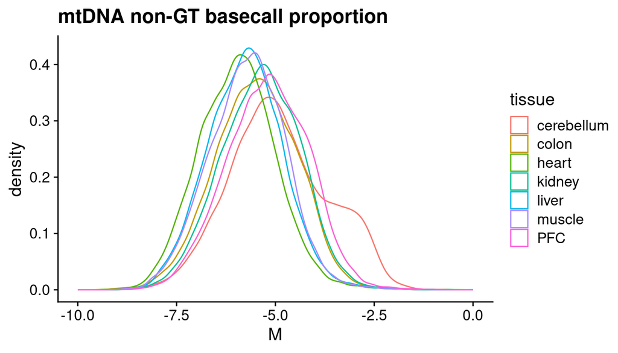

```r
perNucFiles2 <- paste0("../results/depth/",
                       filter(Metadata, platform == "ont", individual_id %in% c("a","b"))$sample_id,
                       "_per_nuc_depth_chrM.txt")
names(perNucFiles2) <- filter(Metadata, platform == "ont", individual_id %in% c("a","b"))$sample_id
#all(file.exists(perNucFiles2))


perNucCov2 <- lapply(names(perNucFiles2), function(sid) {
    read_tsv(perNucFiles2[sid], col_select = c(1,2,4,6,8,10),
             c("seq", "pos", "a", "A", "c", "C", "g", "G", "t", "T")) %>%
        mutate(sample_id = sid)
}) %>% Reduce("bind_rows", .) %>%
    mutate(Cov = A + C + G + T)

mut_load <- perNucCov2 %>%
    pivot_longer(A:T, names_to = "base", values_to = "count") %>%
    arrange(sample_id, pos, desc(count)) %>%
    group_by(sample_id, pos) %>%
    mutate(hom_GT = base[1]) %>%
    mutate(right = count[1]) %>%
    select(sample_id, pos, Cov, right) %>%
    distinct() %>%
    filter(pos != 3107) %>%
    left_join(select(Metadata, sample_id, tissue), by = join_by(sample_id)) %>%
    mutate(mut_load = (Cov - right)/Cov)
mut_load$mut_load <- transf.betareg(mut_load$mut_load)
mut_load$M <- log2(mut_load$mut_load / (1 - mut_load$mut_load))

Plot4_dist <- mut_load %>% ggplot(aes(x = M)) +
    geom_density(aes(colour = tissue)) +
    ggtitle("mtDNA non-GT basecall proportion") +
    xlim(-10, 0)


Plot4_dist
```

```r
invisible(png("./Figs/MT_M_dist.png", height = 1000, width = 1500, res = 150))
Plot4_dist
invisible(dev.off())
```

This represents an average mutational load in the entire mtDNA population.

```r
mut_load %>% group_by(sample_id) %>%
    summarise(mean_mut_load = formatC(mean(mut_load), format = "g", digits = 3, flag = "#"),
              stdev_mut_load = formatC(sd(mut_load), format = "g", flag = "#", digits = 3),
              mean_M = formatC(mean(M), digits = 3, format = "g", flag = "#"),
              stdev_M = formatC(sd(M), digits = 3, format = "g", flag = "#")) %>%
    left_join(Metadata %>% select(sample_id, tissue), by = join_by(sample_id)) %>%
    kable(caption = "Non-GT basecall proportions") %>%
    kable_styling(bootstrap_options = "striped", full_width = FALSE)
```

Non-GT basecall proportions

| sample_id | mean_mut_load | stdev_mut_load | mean_M | stdev_M | tissue |
| --- | --- | --- | --- | --- | --- |
| 6226-CT-0010 | 0.0331 | 0.0250 | -5.20 | 1.03 | PFC |
| 6226-CT-0011 | 0.0198 | 0.0172 | -5.96 | 0.973 | heart |
| 6226-CT-0012 | 0.0231 | 0.0182 | -5.71 | 0.962 | muscle |
| 6226-CT-0013 | 0.0224 | 0.0186 | -5.76 | 0.959 | liver |
| 6226-CT-0014 | 0.0292 | 0.0219 | -5.37 | 1.00 | kidney |
| 6226-CT-0015 | 0.0274 | 0.0211 | -5.49 | 1.04 | colon |
| 6226-CT-0018 | 0.0443 | 0.0392 | -4.91 | 1.25 | cerebellum |

## Deletions

### Distribution of ONT read lengths

A first rough estimate of the presence and abundance of deletions is the length of the mtDNA-aligned reads.

The density plots show the distribution of ONT read lengths aligned to either the mtDNA (rCRS) or the chr22. The vertical dashed line indicates the rCRS length (16,569).

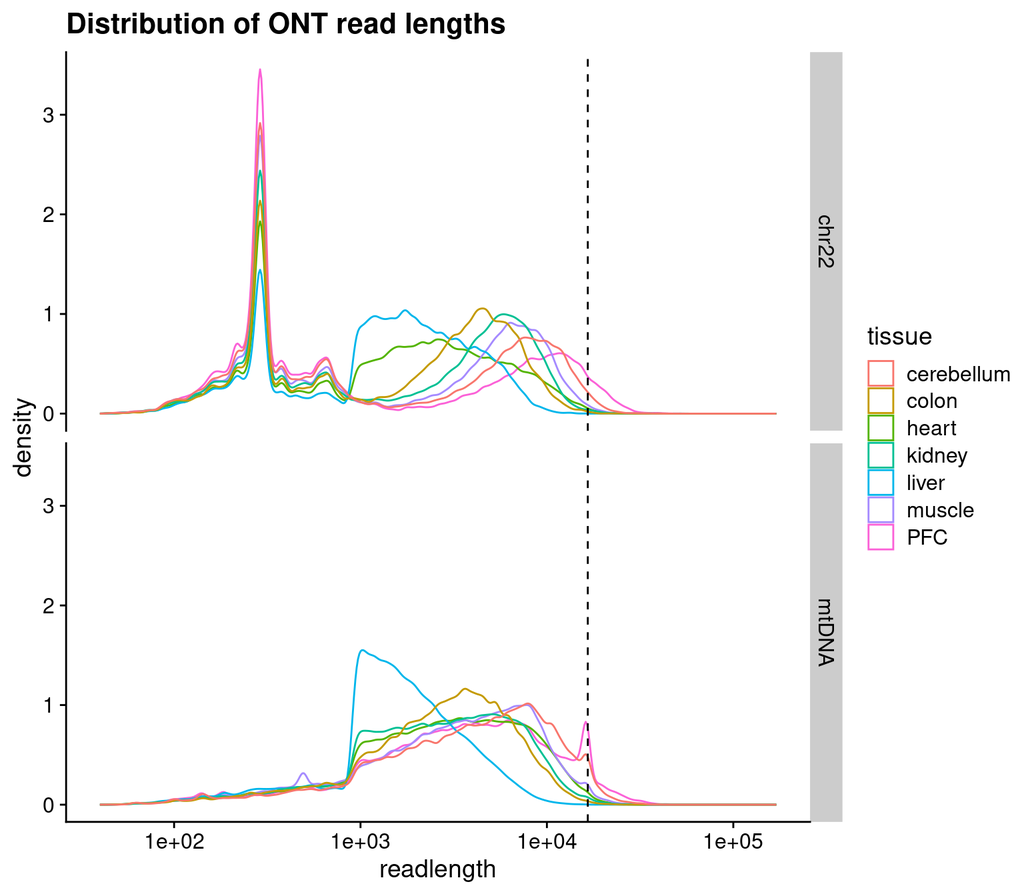

We now test whether the sizes of reads are (significantly) different between tissues.

Using pairwise Wilcoxon tests first:

```r
#require('rstatix')
#compare_means(readlength ~ tissue, data = Len %>%
#              left_join(Metadata %>% select(sample_id, individual_id, tissue), by = join_by(sample_id)) %>%
#              filter(individual_id %in% c("a", "b")))
Tissues <- Metadata %>% filter(individual_id %in% c("a", "b")) %>% pull(tissue)
my_comparisons <- lapply(1:(length(Tissues)-1), function(i) lapply((i+1):length(Tissues), function(j) return(c(Tissues[i],Tissues[j])))) %>%
    unlist(recursive = F)

Mean_readlengths <- Len %>%
    left_join(Metadata %>% select(sample_id, individual_id, tissue), by = join_by(sample_id)) %>%
    filter(readlength != 0, chr == "mtDNA") %>%
    group_by(individual_id, tissue) %>%
    summarise(mean_readlength = mean(readlength), sd_readlength = sd(readlength), .groups = "drop") %>%
    arrange(mean_readlength)

Mean_readlengths %>%
    kable(caption = "Mean read lengths in all tissues") %>%
    kable_styling(bootstrap_options = "striped", full_width = FALSE)
```

Mean read lengths in all tissues

| individual_id | tissue | mean_readlength | sd_readlength |
| --- | --- | --- | --- |
| b | liver | 2094.770 | 1637.708 |
| b | colon | 3603.213 | 2798.363 |
| b | kidney | 3752.619 | 3214.377 |
| b | heart | 4180.276 | 3678.091 |
| b | muscle | 4557.947 | 3870.625 |
| b | cerebellum | 5540.020 | 4714.173 |
| a | PFC | 5551.457 | 5471.243 |
| c | edta_blood | 9726.238 | 6218.360 |
| d | edta_blood | 10721.683 | 7168.907 |

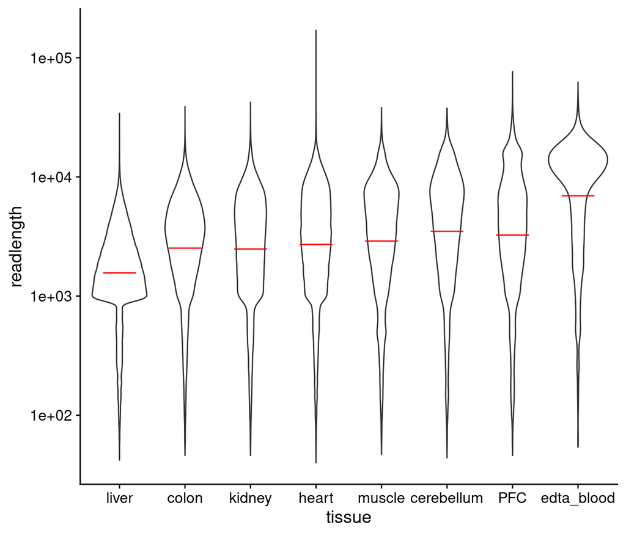

```r
lenBoxPlot <- Len %>%
    left_join(Metadata %>% select(sample_id, individual_id, tissue), by = join_by(sample_id)) %>%
    filter(readlength != 0, chr == "mtDNA") %>%
    mutate(tissue = factor(tissue, levels = unique(Mean_readlengths$tissue))) %>%
    ggplot(aes(x = tissue, y = readlength)) +
    geom_violin() +
    stat_summary(fun = mean, geom = "crossbar",
               width = 0.5, fatten = 1, color = "red") +
    scale_y_log10()

lenBoxPlot
```

```r
invisible(svg("./Figs/read_length_violin_plot.svg", height = 6, width = 12))
lenBoxPlot
invisible(dev.off())

Len %>%
    left_join(Metadata %>% select(sample_id, individual_id, tissue), by = join_by(sample_id)) %>%
    filter(readlength != 0, chr == "mtDNA") %>%
    kruskal.test(formula = readlength ~ tissue, data = .)
```

```
##
##  Kruskal-Wallis rank sum test
##
## data:  readlength by tissue
## Kruskal-Wallis chi-squared = 95841, df = 7, p-value < 2.2e-16
```

```r
Len %>%
    left_join(Metadata %>% select(sample_id, individual_id, tissue), by = join_by(sample_id)) %>%
    filter(readlength != 0, chr == "mtDNA") %>%
    compare_means(formula = readlength ~ tissue, data = ., comparisons = my_comparisons, label = "p.signif") %>%
    kable(caption = "Comparison read length across tissues") %>%
    kable_styling(bootstrap_options = "striped", full_width = FALSE)
```

Comparison read length across tissues

.y.

group1

group2

p

p.adj

p.format

p.signif

method

readlength

PFC

heart

0.0000000

0.000

<2e-16

Wilcoxon

readlength

PFC

muscle

0.0000000

0.000

<2e-16

Wilcoxon

readlength

PFC

liver

0.0000000

0.000

<2e-16

Wilcoxon

readlength

PFC

kidney

0.0000000

0.000

<2e-16

Wilcoxon

readlength

PFC

colon

0.0000000

0.000

<2e-16

Wilcoxon

readlength

PFC

edta_blood

0.0000000

0.000

<2e-16

Wilcoxon

readlength

PFC

cerebellum

0.0000000

0.000

<2e-16

Wilcoxon

readlength

heart

muscle

0.0000000

0.000

<2e-16

Wilcoxon

readlength

heart

liver

0.0000000

0.000

<2e-16

Wilcoxon

readlength

heart

kidney

0.0000000

0.000

<2e-16

Wilcoxon

readlength

heart

colon

0.0000000

0.000

<2e-16

Wilcoxon

readlength

heart

edta_blood

0.0000000

0.000

<2e-16

Wilcoxon

readlength

heart

cerebellum

0.0000000

0.000

<2e-16

Wilcoxon

readlength

muscle

liver

0.0000000

0.000

<2e-16

Wilcoxon

readlength

muscle

kidney

0.0000000

0.000

<2e-16

Wilcoxon

readlength

muscle

colon

0.0000000

0.000

<2e-16

Wilcoxon

readlength

muscle

edta_blood

0.0000000

0.000

<2e-16

Wilcoxon

readlength

muscle

cerebellum

0.0000000

0.000

<2e-16

Wilcoxon

readlength

liver

kidney

0.0000000

0.000

<2e-16

Wilcoxon

readlength

liver

colon

0.0000000

0.000

<2e-16

Wilcoxon

readlength

liver

edta_blood

0.0000000

0.000

<2e-16

Wilcoxon

readlength

liver

cerebellum

0.0000000

0.000

<2e-16

Wilcoxon

readlength

kidney

colon

0.0257751

0.026

0.026

Wilcoxon

readlength

kidney

edta_blood

0.0000000

0.000

<2e-16

Wilcoxon

readlength

kidney

cerebellum

0.0000000

0.000

<2e-16

Wilcoxon

readlength

colon

edta_blood

0.0000000

0.000

<2e-16

Wilcoxon

readlength

colon

cerebellum

0.0000000

0.000

<2e-16

Wilcoxon

readlength

edta_blood

cerebellum

0.0000000

0.000

<2e-16

Wilcoxon

### Deletion sizes

Now we compare the distributions of deletion sizes (>100bp) across tissues.

```r
# delFiles1 <- paste0("../results/deletions/",
#                     filter(Metadata, platform == "ont", individual_id %in% c("a","b"))$sample_id,
#                     "_chrM.txt")
# names(delFiles1) <- filter(Metadata, platform == "ont", individual_id %in% c("a","b"))$sample_id
# #all(file.exists(delFiles1))
# delFiles2 <- paste0("../results/deletions/",
#                     filter(Metadata, platform == "ont", individual_id %in% c("a","b"))$sample_id,
#                     "_chrM_shifted.txt")
# names(delFiles2) <- filter(Metadata, platform == "ont", individual_id %in% c("a","b"))$sample_id
# #all(file.exists(delFiles2))

delFiles1 <- paste0("../results/deletions/",
                    filter(Metadata, platform == "ont")$sample_id,
                    "_chrM.txt")
names(delFiles1) <- filter(Metadata, platform == "ont")$sample_id
#all(file.exists(delFiles1))
delFiles2 <- paste0("../results/deletions/",
                    filter(Metadata, platform == "ont")$sample_id,
                    "_chrM_shifted.txt")
names(delFiles2) <- filter(Metadata, platform == "ont")$sample_id
#all(file.exists(delFiles2))

Del1 <- lapply(names(delFiles1), function(sid) {
    #message(sid)
    read_tsv(delFiles1[sid], col_types = "ciiid") %>%
    mutate(sample_id = sid)
}) %>% Reduce("bind_rows", .) %>%
    filter(del_end - del_start > 1)

Del2 <- lapply(names(delFiles2), function(sid) {
    #message(sid)
    read_tsv(delFiles2[sid], col_types = "ciiid") %>%
    mutate(sample_id = sid)
}) %>% Reduce("bind_rows", .) %>%
    filter(del_end - del_start > 1)

Del2$del_start <- sapply(Del2$del_start, us8k)
Del2$del_end <- sapply(Del2$del_end, us8k)

Del <- bind_rows(Del1, Del2) %>%
    group_by(sample_id, read_id, del_start, del_end, read_length, avg_qual) %>%
    summarise(support = n(), .groups = "drop")
rm(Del1, Del2)
invisible(gc())
```

```r
Mean_dellengths <- Del %>%
    mutate(del_size = ifelse(del_start <= del_end,
                         del_end - del_start,
                         del_end + (16569 - del_start))) %>%
    filter(del_size >= 100) %>%
    left_join(Metadata %>% select(sample_id, individual_id, tissue), by = join_by(sample_id)) %>%
    group_by(individual_id, tissue) %>%
    summarise(mean_dellength = mean(del_size), sd_dellength = sd(del_size), .groups = "drop") %>%
    left_join(Mean_readlengths) %>%
    arrange(mean_dellength)

Mean_dellengths %>%
    kable(caption = "Mean deletion lengths in all tissues") %>%
    kable_styling(bootstrap_options = "striped", full_width = FALSE)
```

Mean deletion lengths in all tissues

| individual_id | tissue | mean_dellength | sd_dellength | mean_readlength | sd_readlength |
| --- | --- | --- | --- | --- | --- |
| d | edta_blood | 135.9062 | 32.99986 | 10721.683 | 7168.907 |
| c | edta_blood | 146.6452 | 45.35236 | 9726.238 | 6218.360 |
| b | colon | 285.0698 | 340.70783 | 3603.213 | 2798.363 |
| b | kidney | 524.9053 | 1216.61876 | 3752.619 | 3214.377 |
| b | liver | 687.7709 | 1190.29535 | 2094.770 | 1637.708 |
| b | cerebellum | 727.7200 | 1666.31076 | 5540.020 | 4714.173 |
| b | heart | 1343.2213 | 2499.25087 | 4180.276 | 3678.091 |
| a | PFC | 2164.7570 | 1940.08938 | 5551.457 | 5471.243 |
| b | muscle | 3112.6830 | 3685.76186 | 4557.947 | 3870.625 |

```r
cor.test(Mean_dellengths$mean_dellength, Mean_dellengths$mean_readlength)
```

```
##
##  Pearson's product-moment correlation
##
## data:  Mean_dellengths$mean_dellength and Mean_dellengths$mean_readlength
## t = -0.86299, df = 7, p-value = 0.4167
## alternative hypothesis: true correlation is not equal to 0
## 95 percent confidence interval:
##  -0.8078500  0.4458393
## sample estimates:
##        cor
## -0.3101006
```

Deletion lengths and read lengths are not significantly anticorrelated.

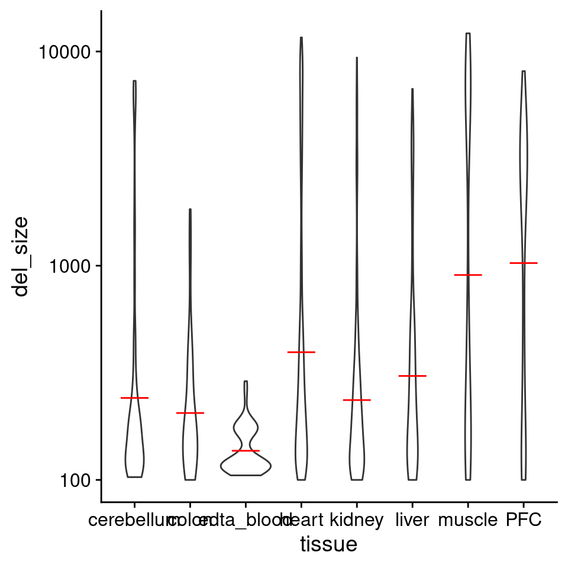

```r
delBoxPlot <- Del %>%
    mutate(del_size = ifelse(del_start <= del_end,
                         del_end - del_start,
                         del_end + (16569 - del_start))) %>%
    filter(del_size >= 100) %>%
    left_join(Metadata %>% select(sample_id, individual_id, tissue), by = join_by(sample_id)) %>%
    ggplot(aes(x = tissue, y = del_size)) +
    geom_violin() +
    stat_summary(fun = mean, geom = "crossbar",
               width = 0.5, fatten = 1, color = "red") +
    scale_y_log10()
    #geom_boxplot(outlier.shape = NA)

delBoxPlot
```

```r
invisible(svg("./Figs/deletion_size_violin_plot.svg", height = 6, width = 12))
delBoxPlot
invisible(dev.off())
```

```r
require('mclust')
require('diptest')

gmm <- Del %>%
    mutate(del_size = ifelse(del_start <= del_end,
                         del_end - del_start,
                         del_end + (16569 - del_start))) %>%
    filter(del_size >= 100) %>%
    left_join(Metadata %>% select(sample_id, individual_id, tissue), by = join_by(sample_id)) %>%
    group_by(tissue) %>%
    summarise(multimodal_p = dip.test(del_size)$p.value,
              GMM_n_clust = Mclust(del_size, G = 1:10)$G,
              GMM_G1_mean = Mclust(del_size, G = 2)$parameters$mean[1],
              GMM_G2_mean = Mclust(del_size, G = 2)$parameters$mean[2])

gmm %>%
    kable(caption = "Multimodality Hartigan's Dip Test p-value and GMM nb. of clusters") %>%
    kable_styling(bootstrap_options = "striped", full_width = FALSE)
```

Multimodality Hartigan’s Dip Test p-value and GMM nb. of clusters

| tissue | multimodal_p | GMM_n_clust | GMM_G1_mean | GMM_G2_mean |
| --- | --- | --- | --- | --- |
| PFC | 0.0189204 | 2 | 127.8421 | 2834.8569 |
| cerebellum | 0.0013410 | 2 | 152.9271 | 2943.1398 |
| colon | 0.0132156 | 5 | 143.7237 | 574.0610 |
| edta_blood | 0.0000000 | 4 | 135.5080 | 141.8283 |
| heart | 0.7768585 | 9 | 212.2317 | 4463.7265 |
| kidney | 0.1959033 | 4 | 182.7468 | 2279.5735 |
| liver | 0.6798143 | 5 | 228.7486 | 2691.5201 |
| muscle | 0.0000226 | 4 | 193.6044 | 5978.3905 |

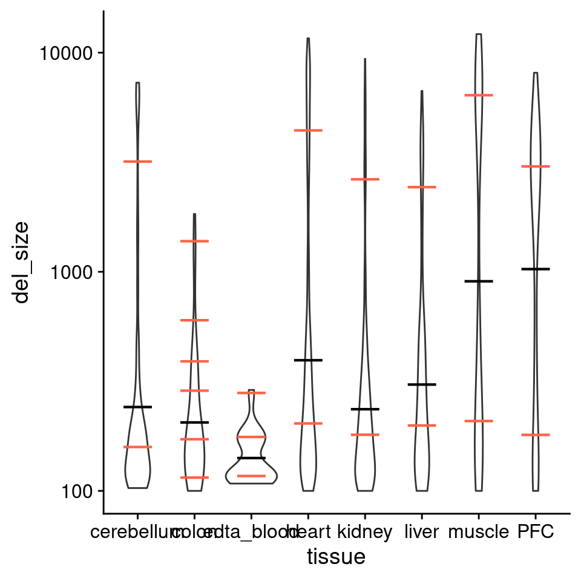

```r
Data <- Del %>%
    mutate(del_size = ifelse(del_start <= del_end,
                         del_end - del_start,
                         del_end + (16569 - del_start))) %>%
    filter(del_size >= 100) %>%
    left_join(Metadata %>% select(sample_id, individual_id, tissue), by = join_by(sample_id)) %>%
    filter(individual_id != "d") %>%
    select(tissue, del_size)

k_values <- 2:10
sil_scores <- sapply(unique(Data$tissue), function(Tissue) {
           sapply(k_values, function(k) {
                    km <- kmeans(data.frame(filter(Data, tissue == Tissue) %>% pull(del_size) %>% log10()),
                                 centers = k, nstart = 25)
                    ss <- cluster::silhouette(km$cluster, dist(filter(Data, tissue == Tissue) %>% pull(del_size) %>% log10()))
                    mean(ss[, 3])  # Average silhouette width
            })
})
rownames(sil_scores) <- k_values
n_clust <- tibble(tissue = names(sapply(as.data.frame(sil_scores), function(x) k_values[which.max(x)])),
                  n_clust = sapply(as.data.frame(sil_scores), function(x) k_values[which.max(x)]))

Data <- left_join(Data, n_clust, by = join_by(tissue))


Data_lst <- split(Data, Data$tissue)

Data2 <- lapply(Data_lst, function(x) {
    k_clust <- as.character(kmeans(data.frame(del_size = log10(x$del_size)), centers = x$n_clust[1], nstart = 25)$cluster)
    x$classification <- k_clust
    return(x)
}) %>% Reduce("bind_rows", .)

delBoxPlot_multimodal <- Data2 %>%
    ggplot(aes(x = tissue, y = del_size)) +
    geom_violin() +
    stat_summary(fun = mean, geom = "crossbar",
               width = 0.5, fatten = 1.5, color = "black") +
    stat_summary(aes(group = classification), fun = mean, geom = "crossbar",
               width = 0.5, fatten = 1.5, color = "Tomato") +
    scale_y_log10()

delBoxPlot_multimodal
```

```r
invisible(svg("./Figs/deletion_size_violin_plot_multimodal.svg", height = 6, width = 12))
delBoxPlot_multimodal
invisible(dev.off())
```

```r
Del %>%
    mutate(del_size = ifelse(del_start <= del_end,
                         del_end - del_start,
                         del_end + (16569 - del_start))) %>%
    filter(del_size >= 100) %>%
    left_join(Metadata %>% select(sample_id, individual_id, tissue), by = join_by(sample_id)) %>%
    kruskal.test(formula = del_size ~ tissue, data = .)
```

```
##
##  Kruskal-Wallis rank sum test
##
## data:  del_size by tissue
## Kruskal-Wallis chi-squared = 248.1, df = 7, p-value < 2.2e-16
```

```r
Del %>%
    mutate(del_size = ifelse(del_start <= del_end,
                         del_end - del_start,
                         del_end + (16569 - del_start))) %>%
    filter(del_size >= 100) %>%
    left_join(Metadata %>% select(sample_id, individual_id, tissue), by = join_by(sample_id)) %>%
    compare_means(formula = del_size ~ tissue, data = ., comparisons = my_comparisons, label = "p.signif") %>%
    mutate(p = formatC(p, digits = 3, format = "g", flag = "#"),
           p.adj = formatC(p.adj, digits = 3, format = "g", flag = "#")) %>%
    kable(caption = "Pairwise tests average deletion size across tissues") %>%
    kable_styling(bootstrap_options = "striped", full_width = FALSE)
```

Pairwise tests average deletion size across tissues

.y.

group1

group2

p

p.adj

p.format

p.signif

method

del_size

PFC

heart

2.29e-15

5.00e-14

2.3e-15

Wilcoxon

del_size

PFC

muscle

0.297

1.00

0.29666

ns

Wilcoxon

del_size

PFC

liver

9.17e-16

2.10e-14

9.2e-16

Wilcoxon

del_size

PFC

kidney

3.99e-20

1.10e-18

< 2e-16

Wilcoxon

del_size

PFC

colon

2.60e-09

4.40e-08

2.6e-09

Wilcoxon

del_size

PFC

edta_blood

1.54e-18

4.20e-17

< 2e-16

Wilcoxon

del_size

PFC

cerebellum

1.43e-12

2.90e-11

1.4e-12

Wilcoxon

del_size

heart

muscle

3.53e-16

8.50e-15

3.5e-16

Wilcoxon

del_size

heart

liver

0.0440

0.260

0.04396

Wilcoxon

del_size

heart

kidney

1.48e-06

2.10e-05

1.5e-06

Wilcoxon

del_size

heart

colon

0.00447

0.0400

0.00447

Wilcoxon

del_size

heart

edta_blood

4.03e-14

8.50e-13

4.0e-14

Wilcoxon

del_size

heart

cerebellum

1.61e-05

0.000190

1.6e-05

Wilcoxon

del_size

muscle

liver

1.74e-12

3.30e-11

1.7e-12

Wilcoxon

del_size

muscle

kidney

5.55e-17

1.40e-15

< 2e-16

Wilcoxon

del_size

muscle

colon

6.50e-07

9.80e-06

6.5e-07

Wilcoxon

del_size

muscle

edta_blood

3.93e-18

1.00e-16

< 2e-16

Wilcoxon

del_size

muscle

cerebellum

4.10e-12

7.40e-11

4.1e-12

Wilcoxon

del_size

liver

kidney

0.0174

0.120

0.01741

Wilcoxon

del_size

liver

colon

0.0607

0.300

0.06070

ns

Wilcoxon

del_size

liver

edta_blood

4.76e-09

7.60e-08

4.8e-09

Wilcoxon

del_size

liver

cerebellum

0.0136

0.110

0.01358

Wilcoxon

del_size

kidney

colon

0.623

1.00

0.62288

ns

Wilcoxon

del_size

kidney

edta_blood

3.45e-06

4.50e-05

3.5e-06

Wilcoxon

del_size

kidney

cerebellum

0.450

1.00

0.44953

ns

Wilcoxon

del_size

colon

edta_blood

0.000954

0.00950

0.00095

***

Wilcoxon

del_size

colon

cerebellum

0.889

1.00

0.88896

ns

Wilcoxon

del_size

edta_blood

cerebellum

0.000163

0.00180

0.00016

***

Wilcoxon

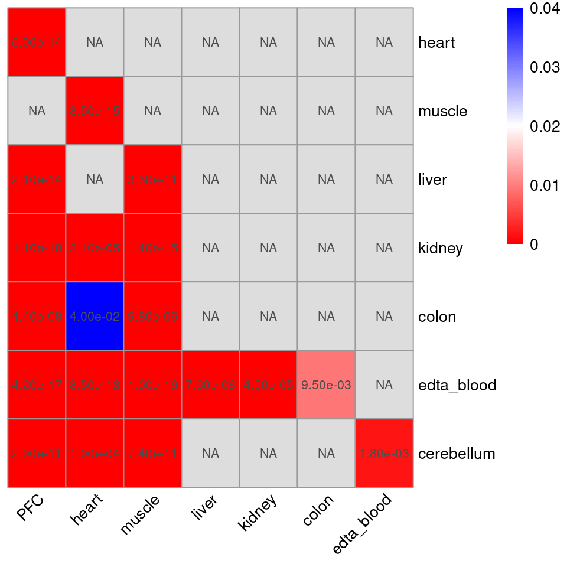

```r
signif_del <- Del %>%
    mutate(del_size = ifelse(del_start <= del_end,
                         del_end - del_start,
                         del_end + (16569 - del_start))) %>%
    filter(del_size >= 100) %>%
    left_join(Metadata %>% select(sample_id, individual_id, tissue), by = join_by(sample_id)) %>%
    compare_means(formula = del_size ~ tissue, data = ., comparisons = my_comparisons, label = "p.signif") %>%
    select(group1, group2, p.adj) %>%
    pivot_wider(names_from = "group1", values_from = "p.adj") %>%
    as.data.frame()
rownames(signif_del) <- signif_del$group2
signif_del <- signif_del[-1]
signif_del[signif_del >= 0.05] <- NA

pheatmap::pheatmap(signif_del, cluster_rows = FALSE, cluster_cols = FALSE,
                   display_numbers = TRUE,
                   number_format = "%.2e",
                   color = colorRampPalette(c("red", "white", "blue"))(100),
                   angle_col = 45)
```

### Deletion events per molecule

We now test differences between tissues in the mean number of big (>100bp) deletion events per read. Since events are integer counts, we model the number of deletion events as a function of tissue using a negative binomial. We choose cerebellum as reference.

```r
Del_tmp <- Del %>%
    mutate(del_size = ifelse(del_start <= del_end,
                         del_end - del_start,
                         del_end + (16569 - del_start))) %>%
    left_join(Metadata %>% select(sample_id, individual_id, tissue), by = join_by(sample_id)) %>%
    mutate(big_del = ifelse(del_size > 100, TRUE, FALSE)) %>%
    group_by(sample_id, read_id, tissue) %>%
    summarise(del_events = n(), big_del_events = sum(big_del), .groups = "drop")

#MASS::glm.nb(del_events ~ tissue, data = Del_tmp) %>%
#    broom::tidy() %>%
#    mutate(estimate = formatC(estimate, format = "g", digits = 3, flag = "#"),
#           std.error = formatC(std.error, format = "g", digits = 3, flag = "#"),
#           statistic = formatC(statistic, format = "g", digits = 3, flag = "#"),
#           p.value = formatC(p.value, format = "g", digits = 3, flag = "#")) %>%
#    kable(caption = "Linear model comparing  read length across tissues") %>%
#    kable_styling(bootstrap_options = "striped", full_width = FALSE)
MASS::glm.nb(big_del_events ~ tissue, data = Del_tmp) %>%
    broom::tidy() %>%
    mutate(estimate = formatC(estimate, format = "g", digits = 3, flag = "#"),
           std.error = formatC(std.error, format = "g", digits = 3, flag = "#"),
           statistic = formatC(statistic, format = "g", digits = 3, flag = "#"),
           p.value = formatC(p.value, format = "g", digits = 3, flag = "#")) %>%
    kable(caption = "Linear model comparing  read length across tissues") %>%
    kable_styling(bootstrap_options = "striped", full_width = FALSE)
```

| term | estimate | std.error | statistic | p.value |
| --- | --- | --- | --- | --- |
| (Intercept) | -4.94 | 0.110 | -44.9 | 0.00 |
| tissuecolon | -0.999 | 0.196 | -5.10 | 3.42e-07 |
| tissueedta_blood | 0.561 | 0.184 | 3.05 | 0.00230 |
| tissueheart | -0.522 | 0.112 | -4.67 | 3.05e-06 |
| tissuekidney | -0.815 | 0.134 | -6.09 | 1.11e-09 |
| tissueliver | -1.84 | 0.129 | -14.2 | 5.62e-46 |
| tissuemuscle | 0.0725 | 0.122 | 0.592 | 0.554 |
| tissuePFC | 0.363 | 0.132 | 2.76 | 0.00574 |

## Deletion breakpoints

Here we plot the deletions larger than 100bp in the mtDNA, based on single reads from the ONT sequencing.

The plots are large and are, therefore, exported into svg images in the Figs/ folder. Only the PFC is plotted here as an example.

```r
# mtDNA gene annotation
mt_genes_df <- readRDS("./Data/EnsDb.Hsapiens.v75.Rds") %>%
    as_tibble() %>%
    filter(seqnames == "MT") %>%
    select(start, end, strand, gene_name, gene_biotype) %>%
    unique() %>%
    mutate(seqnames = factor("mtDNA")) %>%
    mutate(gene_name = str_replace(gene_name, "^MT-", "")) %>%
    mutate(drop = ifelse(gene_name %in% c("ATP6", "ND4", "TQ"), TRUE, FALSE)) %>%
    mutate(big = ifelse(gene_name %in% c("RNR1", "RNR2", "ND1", "ND2",
                                         "CO1", "CO2", "ATP8", "ATP6",
                                         "CO3", "ND3", "ND4L", "ND4",
                                         "ND5", "CYB"), TRUE, FALSE)) %>%
    select(seqnames, everything())
#
#tibble(seqnames = "chrM", start = seq(1,16001, by = 100),
#       end = c(seq(100, 16000, by = 100), 16569)) %>%
#write_tsv("./Data/ranges.bed", col_names = FALSE)
#
##   bedtools nuc -fi /ref/MT/Homo_sapiens_assembly38.chrM.fasta \
##   -bed analyses/Data/ranges.bed | \
##   cut -f1-3,5 > analyses/Data/rCRS_GC_content.tsv
#

# GC content of the mtDNA sequence in 100bp windows
mt_gc_content <- read_tsv("./Data/rCRS_GC_content.tsv",
                          col_names = c("seqnames", "start", "end", "GC_prop"),
                          col_types = "ciid",
                          comment = "#") %>%
    mutate(seqnames = factor("mtDNA"))
for (SID in unique(Del$sample_id)) {
    invisible(svg(paste0("./Figs/circos_", SID, ".svg"), width = 10, height = 10))
    circ_arcs(sid = SID, min_del_len = 100, alpha = 0.5)
    invisible(dev.off())
    invisible(svg(paste0("./Figs/del_cov_circos_", SID, ".svg"), width = 10, height = 10))
    circ_del_cov(sid = SID, min_del_len = 100, alpha = 0.5)
    invisible(dev.off())
}
```

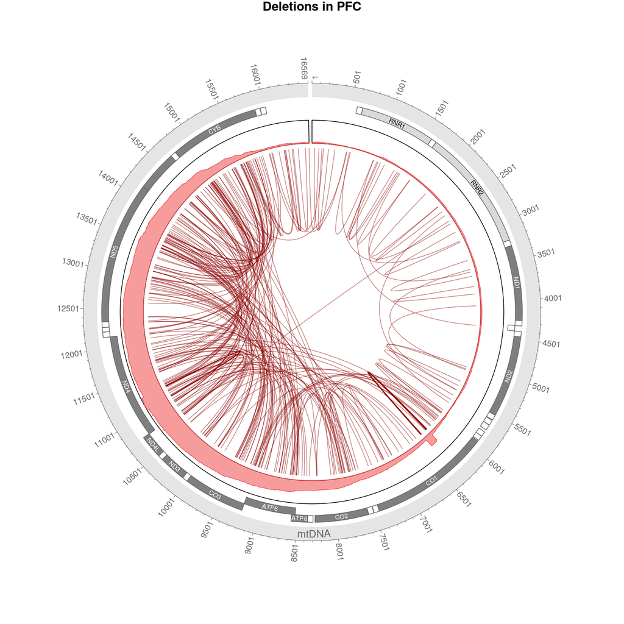

```r
circ_del_cov(sid = "6226-CT-0010", min_del_len = 100, alpha = 0.5)
```

There are two regions in the mtDNA that seem to harbour a higher number of deletions than the rest for most of the samples. The location of these two deletions is del_A: 6,261-6,380; del_B: 11,041-11,219.

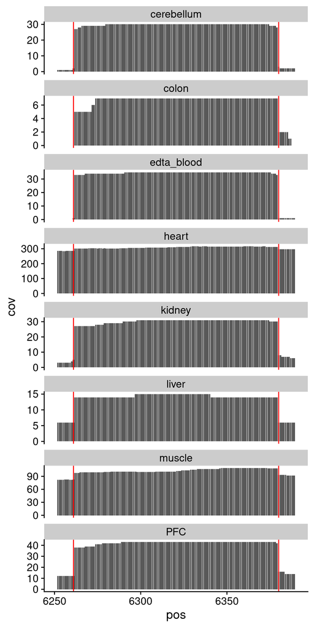

```r
min_del_len <- 100

seqinfo <- Seqinfo(
    seqnames = c("mtDNA"),
    seqlengths = c(16569),
    isCircular = c(TRUE),
    genome = "hg38"
)

non_hanging <- Del %>%
    mutate(del_size = ifelse(del_start <= del_end,
                         del_end - del_start,
                         del_end + (16569 - del_start))) %>%
    filter(del_size >= min_del_len) %>%
    mutate(seqnames = factor("mtDNA")) %>%
    mutate(sample_id = as.factor(sample_id)) %>%
    select(seqnames, start = del_start, end = del_end, sample_id) %>%
    filter(start < end) %>%
    makeGRangesFromDataFrame(seqinfo = seqinfo, keep.extra.columns = TRUE)

hanging <- Del %>%
    mutate(del_size = ifelse(del_start <= del_end,
                         del_end - del_start,
                         del_end + (16569 - del_start))) %>%
    filter(del_size >= min_del_len) %>%
    mutate(seqnames = factor("mtDNA")) %>%
    mutate(sample_id = as.factor(sample_id)) %>%
    select(seqnames, start = del_start, end = del_end, sample_id) %>%
    filter(start > end)

hang_left <- hanging %>%
    mutate(end = 16569) %>%
    makeGRangesFromDataFrame(seqinfo = seqinfo, keep.extra.columns = TRUE)

hang_right <- hanging %>%
    mutate(start = 1) %>%
    makeGRangesFromDataFrame(seqinfo = seqinfo, keep.extra.columns = TRUE)
Del_GR <- c(non_hanging, hang_left, hang_right)
rm(hanging, non_hanging, hang_left, hang_right)
invisible(gc())

# del_A
st_end_A <- c(6261, 6380)
Plot_del_A <- lapply(split(Del_GR, Del_GR$sample_id), function(x) {tibble(pos = 1:16569, cov = as.numeric(coverage(x)$mtDNA))}) %>%
    bind_rows(.id = "sample_id") %>%
    left_join(Metadata %>% select(sample_id, tissue)) %>%
    ggplot() +
    geom_col(aes(x = pos, y = cov)) +
    geom_vline(xintercept = st_end_A, color = "red") +
    facet_wrap(~tissue, ncol = 1, scales = "free_y") +
    xlim(c(st_end_A[1]-10, st_end_A[2]+10))

# del_B

st_end_B <- c(11041, 11219)
Plot_del_B <- lapply(split(Del_GR, Del_GR$sample_id), function(x) {tibble(pos = 1:16569, cov = as.numeric(coverage(x)$mtDNA))}) %>%
    bind_rows(.id = "sample_id") %>%
    left_join(Metadata %>% select(sample_id, tissue)) %>%
    ggplot() +
    geom_col(aes(x = pos, y = cov)) +
    geom_vline(xintercept = st_end_B, color = "red") +
    facet_wrap(~tissue, ncol = 1, scales = "free_y") +
    xlim(c(st_end_B[1]-10, st_end_B[2]+10))

Plot_del_A
```

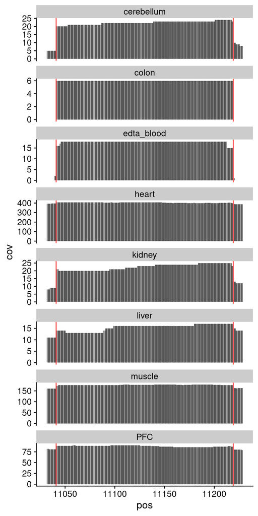

```r
# invisible(svg("./Figs/del_A.svg", height = 12, width = 12))
# Plot_del_A
# invisible(dev.off())
invisible(png("./Figs/del_A.png", height = 2000, width = 2000, res = 150))
Plot_del_A
invisible(dev.off())

Plot_del_B
```

```r
# invisible(svg("./Figs/del_B.svg", height = 12, width = 12))
# Plot_del_B
# invisible(dev.off())
invisible(png("./Figs/del_B.png", height = 2000, width = 2000, res = 150))
Plot_del_B
invisible(dev.off())
```

These regions are covered by deletions but often the deletions covering them are actually spanning longer segments. We can try to quantify (1) how common these regions are “missing” from the mtDNA (i.e., also accounting for longer deletions that span over them), and (2) how relatively common these deletions are with regard to the other deletion events in the mtDNA.

In order to estimate (1), we simply divide the **deletion coverage** in that region with the **sequencing coverage** in the region corresponding to the RNR1 gene, which has consistently low deletion levels in all samples.

```r
med_rnr1_cov <- Cov %>% left_join(Metadata %>% select(sample_id, tissue)) %>%
    filter(Pos > 648, Pos < 1601) %>%
    group_by(tissue) %>%
    summarise(median_rnr1_cov = median(Cov))
# 1)
med_del_cov_A <- lapply(split(Del_GR, Del_GR$sample_id), function(x) {tibble(pos = 1:16569, cov = as.numeric(coverage(x)$mtDNA))}) %>%
    bind_rows(.id = "sample_id") %>%
    left_join(Metadata %>% select(sample_id, tissue)) %>%
    filter(pos >= st_end_A[1]+1, pos <= st_end_A[2]-1) %>%
    group_by(tissue) %>%
    summarise(median_delA_cov = median(cov))
med_del_cov_B <- lapply(split(Del_GR, Del_GR$sample_id), function(x) {tibble(pos = 1:16569, cov = as.numeric(coverage(x)$mtDNA))}) %>%
    bind_rows(.id = "sample_id") %>%
    left_join(Metadata %>% select(sample_id, tissue)) %>%
    filter(pos >= st_end_B[1]+1, pos <= st_end_B[2]-1) %>%
    group_by(tissue) %>%
    summarise(median_delB_cov = median(cov))

full_join(med_del_cov_A, med_del_cov_B) %>%
    left_join(med_rnr1_cov) %>%
    mutate(prop_del_A = median_delA_cov/median_rnr1_cov, rop_del_B = median_delB_cov/median_rnr1_cov) %>%
    kable(caption = "(1) Relative del_A and del_B abundances compared with the coverage") %>%
    kable_styling(bootstrap_options = "striped", full_width = FALSE)
```

Relative del_A and del_B abundances compared with the coverage

| tissue | median_delA_cov | median_delB_cov | median_rnr1_cov | prop_del_A | rop_del_B |
| --- | --- | --- | --- | --- | --- |
| PFC | 43.0 | 89 | 7746.0 | 0.0055513 | 0.0114898 |
| cerebellum | 30.0 | 22 | 3907.0 | 0.0076785 | 0.0056309 |
| colon | 7.0 | 6 | 3351.0 | 0.0020889 | 0.0017905 |
| edta_blood | 16.5 | 9 | 504.0 | 0.0327381 | 0.0178571 |
| heart | 310.5 | 406 | 206118.0 | 0.0015064 | 0.0019697 |
| kidney | 31.0 | 23 | 13066.0 | 0.0023726 | 0.0017603 |
| liver | 14.0 | 16 | 20429.0 | 0.0006853 | 0.0007832 |
| muscle | 101.5 | 178 | 17911.5 | 0.0056668 | 0.0099377 |

To estimate (2), we divide the **number of the specific deletion event** (del_A or del_B, within +10/-10bps) by the **total number of deletion events** found in the sample.

```r
nb_del <- Del %>% mutate(del_size = ifelse(del_start <= del_end,
                         del_end - del_start,
                         del_end + (16569 - del_start))) %>%
    filter(del_size >= 100) %>%
    left_join(Metadata %>% select(sample_id, individual_id, tissue), by = join_by(sample_id)) %>%
    group_by(tissue) %>%
    summarise(nb_del = n())

nb_del_A <- Del %>% filter(del_start > st_end_A[1]-10, del_start < st_end_A[1]+10,
               del_end > st_end_A[2]-10, del_end < st_end_A[2]+10) %>%
    left_join(Metadata %>% select(sample_id, tissue)) %>%
    group_by(tissue) %>%
    summarise(nb_del_A = n())


nb_del_B <- Del %>% filter(del_start > st_end_B[1]-10, del_start < st_end_B[1]+10,
               del_end > st_end_B[2]-10, del_end < st_end_B[2]+10) %>%
    left_join(Metadata %>% select(sample_id, tissue)) %>%
    group_by(tissue) %>%
    summarise(nb_del_B = n())

inner_join(nb_del_A, nb_del_B) %>%
    left_join(nb_del) %>%
    mutate(prop_del_A = nb_del_A / nb_del, prop_del_B = nb_del_B / nb_del) %>%
    kable(caption = "(2a) Relative del_A and del_B abundances compared to number of deletion events") %>%
    kable_styling(bootstrap_options = "striped", full_width = FALSE)
```

(2a) Relative del_A and del_B abundances compared to number of deletion events

| tissue | nb_del_A | nb_del_B | nb_del | prop_del_A | prop_del_B |
| --- | --- | --- | --- | --- | --- |
| PFC | 27 | 7 | 251 | 0.1075697 | 0.0278884 |
| cerebellum | 28 | 15 | 100 | 0.2800000 | 0.1500000 |
| colon | 5 | 6 | 43 | 0.1162791 | 0.1395349 |
| edta_blood | 34 | 18 | 63 | 0.5396825 | 0.2857143 |
| heart | 18 | 12 | 2783 | 0.0064678 | 0.0043119 |
| kidney | 24 | 13 | 190 | 0.1263158 | 0.0684211 |
| liver | 8 | 3 | 227 | 0.0352423 | 0.0132159 |
| muscle | 16 | 15 | 429 | 0.0372960 | 0.0349650 |

Alternatively, we also divide the number of del_A and del_B deletions by the total number of mtDNA reads.

```r
nb_reads <- Len %>% select(readname, sample_id) %>%
    left_join(Metadata %>% select(sample_id, tissue)) %>%
    group_by(tissue) %>%
    summarise(nb_reads = n())

inner_join(nb_del_A, nb_del_B) %>%
    left_join(nb_reads) %>%
    mutate(prop_del_A = nb_del_A / nb_reads, prop_del_B = nb_del_B / nb_reads) %>%
    kable(caption = "(2b) Relative del_A and del_B abundances compared to number of reads") %>%
    kable_styling(bootstrap_options = "striped", full_width = FALSE)
```

(2b) Relative del_A and del_B abundances compared to number of reads

| tissue | nb_del_A | nb_del_B | nb_reads | prop_del_A | prop_del_B |
| --- | --- | --- | --- | --- | --- |
| PFC | 27 | 7 | 88888 | 0.0003038 | 0.0000788 |
| cerebellum | 28 | 15 | 87230 | 0.0003210 | 0.0001720 |
| colon | 5 | 6 | 48835 | 0.0001024 | 0.0001229 |
| edta_blood | 34 | 18 | 72287 | 0.0004703 | 0.0002490 |
| heart | 18 | 12 | 1160273 | 0.0000155 | 0.0000103 |
| kidney | 24 | 13 | 165774 | 0.0001448 | 0.0000784 |
| liver | 8 | 3 | 299504 | 0.0000267 | 0.0000100 |
| muscle | 16 | 15 | 153219 | 0.0001044 | 0.0000979 |